# DIF Exercises: Group 1 — Solutions

Derek Briggs

2026-04-19

# 1 Overview

In this assignment you will apply the DIF detection methods covered in class to a **simulated** dataset. The data contain 2,000 examinees (1,000 per gender group), 28 dichotomous items, and a gender indicator variable (`Male`: 0 = Female, 1 = Male). Some of the items were simulated to contain DIF. Your task is to find them using both the Mantel-Haenszel approach and the `lordif` approach, and to compare the results.

# 2 The Ground Truth

Because this is simulated data, we know exactly which items contain DIF and the nature of that DIF. This section reveals the generating parameters so we can evaluate how well each detection method performs.

**Impact (group ability differences):**

- Female $\theta \sim N(0.8, 1.0)$
- Male $\theta \sim N(1.2, 1.1)$
- Males have higher mean ability and slightly more variability

**DIF items:** 5 of 28 items contain DIF. The DIF is **mixed in direction** — 3 items favor males and 2 favor females:

```r
library(kableExtra)

truth <- data.frame(
  Item = c(5, 10, 15, 20, 25),
  Direction = c("Favors Males", "Favors Males", "Favors Males",
                "Favors Females", "Favors Females"),
  b_shift = c("1.0 logits harder for females",
              "0.7 logits harder for females",
              "0.5 logits harder for females",
              "0.5 logits harder for males",
              "0.7 logits harder for males"),
  DIF_Type = c("Uniform", "Uniform", "Non-uniform",
               "Uniform", "Uniform"),
  Notes = c("", "",
            "Male discrimination is 0.2 higher than female",
            "", "")
)

truth |>
  kable("html",
        col.names = c("Item", "Direction", "Difficulty Shift",
                       "DIF Type", "Notes")) |>
  kable_styling(full_width = FALSE)
```

| Item | Direction | Difficulty Shift | DIF Type | Notes |
| --- | --- | --- | --- | --- |
| 5 | Favors Males | 1.0 logits harder for females | Uniform |  |
| 10 | Favors Males | 0.7 logits harder for females | Uniform |  |
| 15 | Favors Males | 0.5 logits harder for females | Non-uniform | Male discrimination is 0.2 higher than female |
| 20 | Favors Females | 0.5 logits harder for males | Uniform |  |
| 25 | Favors Females | 0.7 logits harder for males | Uniform |  |

Key features of this dataset:

- The DIF is **mixed in direction**, so we would expect partial cancellation at the test level
- Item 15 is the only item with **non-uniform DIF** (different discrimination parameters across groups) — this will be important when comparing MH to `lordif`
- The DIF magnitudes range from moderate (0.5 logits) to large (1.0 logit)
- The remaining 23 items have identical parameters for males and females

With this ground truth in mind, let’s see what the MH and `lordif` methods recover.

# 3 Exercise 1: Load and Explore the Data

Load the dataset `DIF.data1.csv`. Examine the structure of the data using `head()`, `tail()`, `nrow()`, and `ncol()`. Convert the `Male` variable to a factor with labels “Female” and “Male”.

```r
# Load the data
DIF.data <- read.csv("DIF.data1.csv")

# Convert Male to a factor
DIF.data$Male <- factor(DIF.data$Male, levels = c(0, 1),
                        labels = c("Female", "Male"))

# Explore the data
head(DIF.data)
```

```
##   V1 V2 V3 V4 V5 V6 V7 V8 V9 V10 V11 V12 V13 V14 V15 V16 V17 V18 V19 V20 V21
## 1  1  1  1  1  1  0  1  1  1   1   1   1   1   1   1   1   1   0   1   1   1
## 2  1  1  1  1  0  1  1  1  1   0   1   0   1   0   1   1   0   1   1   1   1
## 3  1  0  1  1  0  1  1  1  1   1   1   1   1   0   1   1   1   1   1   1   1
## 4  0  1  1  1  1  1  0  1  1   0   1   1   1   0   1   1   1   1   1   1   1
## 5  1  0  0  1  0  0  1  1  1   1   1   0   1   0   0   1   1   1   1   1   0
## 6  1  1  1  1  0  0  1  1  0   1   1   0   1   1   0   0   1   1   1   1   1
##   V22 V23 V24 V25 V26 V27 V28   Male
## 1   1   1   0   1   1   1   1 Female
## 2   0   1   1   1   1   1   1 Female
## 3   1   1   1   1   1   0   0 Female
## 4   1   1   1   1   1   1   1 Female
## 5   0   0   1   1   1   1   0 Female
## 6   0   1   1   0   1   1   1 Female
```

```r
tail(DIF.data)
```

```
##      V1 V2 V3 V4 V5 V6 V7 V8 V9 V10 V11 V12 V13 V14 V15 V16 V17 V18 V19 V20 V21
## 1995  1  1  1  1  1  1  1  0  1   1   1   1   1   1   0   1   1   0   1   0   1
## 1996  0  1  1  0  1  1  0  1  1   1   1   1   0   1   1   1   0   0   1   0   1
## 1997  1  1  1  1  0  1  0  1  1   0   1   0   1   1   1   1   1   1   1   1   1
## 1998  0  1  0  0  0  0  1  0  1   0   0   0   1   1   0   1   1   0   1   1   0
## 1999  0  1  0  1  0  1  0  0  1   1   0   0   1   0   0   1   1   0   0   0   0
## 2000  1  1  1  0  1  1  1  1  1   1   1   1   1   1   1   1   1   1   1   1   1
##      V22 V23 V24 V25 V26 V27 V28 Male
## 1995   1   0   1   0   1   1   0 Male
## 1996   1   1   1   0   1   1   0 Male
## 1997   1   1   0   0   1   0   1 Male
## 1998   1   1   1   1   1   0   1 Male
## 1999   1   0   0   1   0   0   0 Male
## 2000   1   1   1   1   0   1   1 Male
```

```r
nrow(DIF.data)
```

```
## [1] 2000
```

```r
ncol(DIF.data)
```

```
## [1] 29
```

**Question 1a**: How many examinees are in each gender group?

> There are 1,000 females and 1,000 males, for a total of 2,000 examinees.

```r
table(DIF.data$Male)
```

```
##
## Female   Male
##   1000   1000
```

**Question 1b**: Examine the unconditional proportions correct by gender for all 28 items. Which items show the largest unconditional differences between groups? List any items where the difference in proportion correct exceeds 5 percentage points.

```r
library(kableExtra)

p_f <- colMeans(DIF.data[DIF.data$Male == "Female", 1:28])
p_m <- colMeans(DIF.data[DIF.data$Male == "Male", 1:28])
pdiff <- p_m - p_f

uncond <- data.frame(
  Item = 1:28,
  p_Female = round(p_f, 3),
  p_Male = round(p_m, 3),
  Diff = round(pdiff, 3),
  Flag = ifelse(abs(pdiff) > 0.05, "*", "")
)

uncond |>
  kable("html",
        col.names = c("Item", "p (Female)", "p (Male)",
                       "Diff (M - F)", "Flag")) |>
  kable_styling(full_width = FALSE)
```

p (Male)

Diff (M - F)

Flag

V1

1

0.608

0.641

0.033

V2

2

0.708

0.754

0.046

V3

3

0.631

0.691

0.060

V4

4

0.595

0.638

0.043

V5

5

0.496

0.575

0.079

V6

6

0.580

0.666

0.086

V7

7

0.744

0.776

0.032

V8

8

0.490

0.532

0.042

V9

9

0.871

0.893

0.022

V10

10

0.537

0.686

0.149

V11

11

0.880

0.919

0.039

V12

12

0.604

0.657

0.053

V13

13

0.723

0.758

0.035

V14

14

0.486

0.577

0.091

V15

15

0.578

0.697

0.119

V16

16

0.609

0.670

0.061

V17

17

0.648

0.702

0.054

V18

18

0.585

0.652

0.067

V19

19

0.593

0.662

0.069

V20

20

0.617

0.594

-0.023

V21

21

0.661

0.727

0.066

V22

22

0.615

0.677

0.062

V23

23

0.516

0.590

0.074

V24

24

0.750

0.795

0.045

V25

25

0.693

0.668

-0.025

V26

26

0.723

0.768

0.045

V27

27

0.606

0.677

0.071

V28

28

0.688

0.733

0.045

# 4 Exercise 2: DIF Analysis Using Mantel-Haenszel

## 4.1 2a: Create the matching criterion

Compute total scores for all examinees. Collapse total scores into decile bins using the `quantile()` function to create a grouping variable called `diftot`.

```r
# Compute total scores
DIF.data$total <- rowSums(DIF.data[, 1:28])

# Distribution of total scores
table(DIF.data$total)
```

```
##
##   3   4   6   7   8   9  10  11  12  13  14  15  16  17  18  19  20  21  22  23
##   1   1   6  14  16  29  36  57  63  87 104 122 141 138 119 162 153 132 150 129
##  24  25  26  27  28
## 117  93  64  46  20
```

```r
# Create decile bins
x <- quantile(DIF.data$total, probs = seq(0, 1, 0.10))
diftot <- rep(0, nrow(DIF.data))
for (i in 1:(length(x) - 1)) {
  diftot[DIF.data$total >= x[i] & DIF.data$total < x[i + 1]] <- i
}
diftot[DIF.data$total == max(DIF.data$total)] <- length(x) - 1

table(diftot)
```

```
## diftot
##   1   2   3   4   5   6   7   8   9  10
## 160 150 226 141 257 162 285 150 246 223
```

## 4.2 2b: Compute MH statistics

Compute the Mantel-Haenszel statistic for each of the 28 items. Extract the odds ratios and p-values.

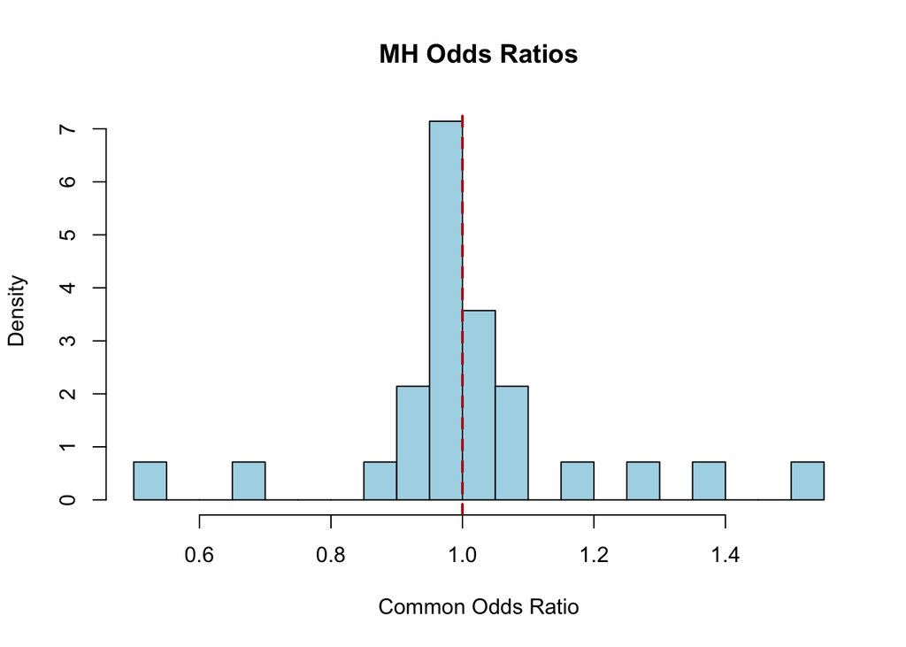

```r
mh_or <- rep(0, 28)
mh_pval <- rep(0, 28)

for (i in 1:28) {
  temp <- mantelhaen.test(DIF.data[, i], y = DIF.data$Male, z = diftot,
                          alternative = "two.sided", conf.level = 0.95)
  mh_or[i] <- temp$estimate
  mh_pval[i] <- temp$p.value
}

# Visualize odds ratios
hist(mh_or, breaks = 15, main = "MH Odds Ratios", xlab = "Common Odds Ratio",
     col = "lightblue", freq = FALSE)
abline(v = 1, col = "firebrick", lwd = 2, lty = 2)
```

## 4.3 2c: ETS delta classification

Transform the MH odds ratios into ETS delta statistics. Classify each item as Level A, B, or C.

```r
delta <- -2.35 * log(mh_or)

# Classification
level <- ifelse(abs(delta) >= 1.5, "C",
          ifelse(abs(delta) > 1, "B", "A"))

# Direction: positive delta = favors females, negative delta = favors males
direction <- ifelse(delta > 0, "Favors Females", "Favors Males")

# Summary table
mh_results <- data.frame(
  Item = 1:28,
  OR = round(mh_or, 3),
  Delta = round(delta, 3),
  p_value = round(mh_pval, 4),
  Significant = ifelse(mh_pval < 0.05, "Yes", "No"),
  Direction = direction,
  Level = level
)

mh_results |>
  kable("html") |>
  kable_styling(full_width = FALSE)
```

| Item | OR | Delta | p_value | Significant | Direction | Level |
| --- | --- | --- | --- | --- | --- | --- |
| 1 | 0.889 | 0.277 | 0.2613 | No | Favors Females | A |
| 2 | 1.024 | -0.057 | 0.8641 | No | Favors Males | A |
| 3 | 0.925 | 0.184 | 0.5169 | No | Favors Females | A |
| 4 | 0.920 | 0.195 | 0.4375 | No | Favors Females | A |
| 5 | 1.263 | -0.549 | 0.0130 | Yes | Favors Males | A |
| 6 | 1.053 | -0.122 | 0.6643 | No | Favors Males | A |
| 7 | 0.981 | 0.045 | 0.9059 | No | Favors Females | A |
| 8 | 0.975 | 0.059 | 0.8283 | No | Favors Females | A |
| 9 | 0.985 | 0.036 | 0.9738 | No | Favors Females | A |
| 10 | 1.548 | -1.028 | 0.0000 | Yes | Favors Males | B |
| 11 | 1.168 | -0.366 | 0.3715 | No | Favors Males | A |
| 12 | 1.000 | 0.001 | 0.9973 | No | Favors Females | A |
| 13 | 0.954 | 0.110 | 0.7058 | No | Favors Females | A |
| 14 | 1.087 | -0.197 | 0.4452 | No | Favors Males | A |
| 15 | 1.368 | -0.736 | 0.0020 | Yes | Favors Males | A |
| 16 | 1.027 | -0.062 | 0.8296 | No | Favors Males | A |
| 17 | 0.944 | 0.136 | 0.6232 | No | Favors Females | A |
| 18 | 1.045 | -0.104 | 0.6939 | No | Favors Males | A |
| 19 | 1.024 | -0.055 | 0.8594 | No | Favors Males | A |
| 20 | 0.539 | 1.451 | 0.0000 | Yes | Favors Females | B |
| 21 | 0.996 | 0.009 | 0.9737 | No | Favors Females | A |
| 22 | 0.996 | 0.010 | 0.9687 | No | Favors Females | A |
| 23 | 1.062 | -0.141 | 0.5713 | No | Favors Males | A |
| 24 | 0.997 | 0.007 | 0.9807 | No | Favors Females | A |
| 25 | 0.698 | 0.844 | 0.0006 | Yes | Favors Females | A |
| 26 | 0.987 | 0.030 | 0.9521 | No | Favors Females | A |
| 27 | 1.011 | -0.025 | 0.9624 | No | Favors Males | A |
| 28 | 0.984 | 0.039 | 0.9185 | No | Favors Females | A |

```r
# Level counts
cat("Level A (negligible):", sum(level == "A"), "\n")
```

```
## Level A (negligible): 26
```

```r
cat("Level B (moderate):  ", sum(level == "B"), "\n")
```

```
## Level B (moderate):   2
```

```r
cat("Level C (large):     ", sum(level == "C"), "\n")
```

```
## Level C (large):      0
```

**Question 2**: Based on the MH analysis, which items would you flag for DIF? For each flagged item, indicate: (a) the direction of DIF (which group is disadvantaged), (b) whether the result is statistically significant, and (c) the ETS classification level.

> Five items are statistically significant (p < .05) and show varying magnitudes of DIF, but none reach level C on the ETS taxonomy:
> - **Item 5**: OR = 1.26, delta = -0.55, Level A, favors males. Statistically significant but small effect.
> - **Item 10**: OR = 1.55, delta = -1.03, Level B, favors males. Moderate DIF — females are disadvantaged on this item after conditioning on total score.
> - **Item 15**: OR = 1.37, delta = -0.74, Level A, favors males. Significant but classified as negligible by ETS criteria.
> - **Item 20**: OR = 0.54, delta = +1.45, Level B, favors females. Moderate DIF — males are disadvantaged on this item.
> - **Item 25**: OR = 0.70, delta = +0.84, Level A, favors females. Significant but small effect.

> Items 10 and 20 are the most concerning (Level B). Note the mixed directionality: items 5, 10, and 15 favor males, while items 20 and 25 favor females. The remaining 23 items show no evidence of DIF.

# 5 Exercise 3: DIF Analysis Using lordif

## 5.1 3a: Run lordif

Reload the data (without the factor conversion) and run the `lordif` algorithm with the $\chi^2$ criterion at $\alpha$ = 0.01.

```r
library(lordif)

# Reload data as numeric
DIF.data <- read.csv("DIF.data1.csv")

# Run lordif
dif_result <- lordif(DIF.data[, 1:28], DIF.data[, 29],
                     criterion = "Chisqr", alpha = 0.01, minCell = 5)
```

```
##  (mirt) | Iteration: 1, 5 items flagged for DIF (5,10,15,20,25)
##  (mirt) | Iteration: 2, 5 items flagged for DIF (5,10,15,20,25)
```

## 5.2 3b: Examine and interpret results

Use `print()` to examine the flagged items and their associated statistics.

```r
print(dif_result)
```

```
## Call:
## lordif(resp.data = DIF.data[, 1:28], group = DIF.data[, 29],
##     criterion = "Chisqr", alpha = 0.01, minCell = 5)
##
##   Number of DIF groups: 2
##
##   Number of items flagged for DIF: 5 of 28
##
##   Items flagged: 5, 10, 15, 20, 25
##
##   Number of iterations for purification: 2 of 10
##
##   Detection criterion: Chisqr
##
##   Threshold: alpha = 0.01
##
##    item ncat  chi12  chi13  chi23
## 1     1    2 0.3627 0.6375 0.7886
## 2     2    2 0.6169 0.6270 0.4085
## 3     3    2 0.4411 0.4984 0.3713
## 4     4    2 0.6014 0.8596 0.8631
## 5     5    2 0.0018 0.0071 0.6588
## 6     6    2 0.6317 0.7390 0.5402
## 7     7    2 0.8521 0.9103 0.6955
## 8     8    2 0.9294 0.9790 0.8526
## 9     9    2 0.9719 0.9627 0.7846
## 10   10    2 0.0000 0.0000 0.1952
## 11   11    2 0.2862 0.1668 0.1180
## 12   12    2 0.7212 0.9174 0.8321
## 13   13    2 0.8723 0.9705 0.8538
## 14   14    2 0.3598 0.5013 0.4614
## 15   15    2 0.0004 0.0000 0.0003
## 16   16    2 0.5202 0.7116 0.6053
## 17   17    2 0.8658 0.9185 0.7069
## 18   18    2 0.5371 0.6679 0.5138
## 19   19    2 0.6753 0.8624 0.7284
## 20   20    2 0.0000 0.0000 0.8070
## 21   21    2 0.8975 0.9650 0.8150
## 22   22    2 0.9874 0.9479 0.7438
## 23   23    2 0.3263 0.2306 0.1604
## 24   24    2 0.8826 0.8985 0.6610
## 25   25    2 0.0011 0.0047 0.8209
## 26   26    2 0.9566 0.9469 0.7444
## 27   27    2 0.7943 0.9109 0.7304
## 28   28    2 0.9716 0.9931 0.9110
```

**Question 3a**: Which items were flagged by `lordif`? How many iterations did the algorithm require?

> `lordif` flagged **5 items**: 5, 10, 15, 20, and 25. The algorithm converged in **2 iterations**—the same 5 items were flagged in both iterations, so the purification process stabilized immediately.

## 5.3 3c: Diagnostic plots

Generate the diagnostic plots and examine them carefully.

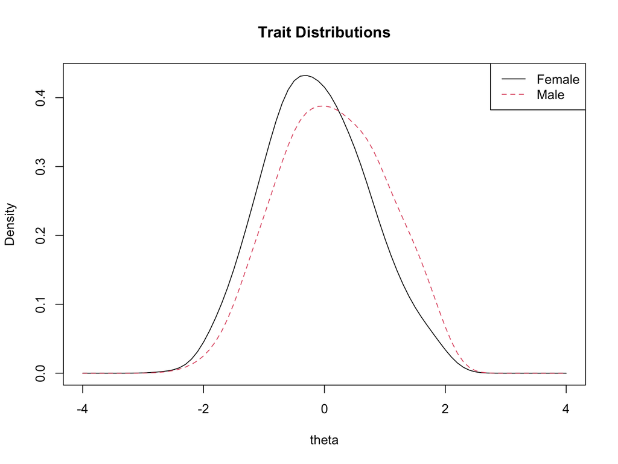

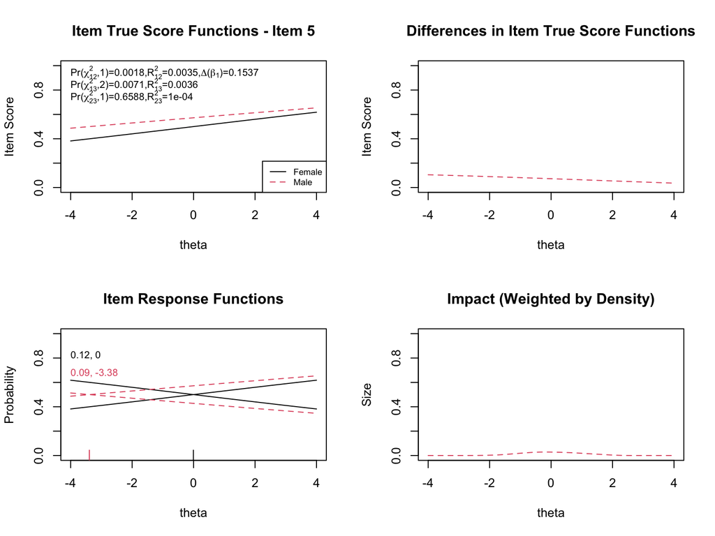

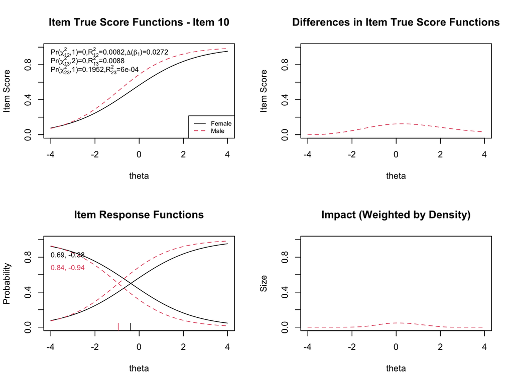

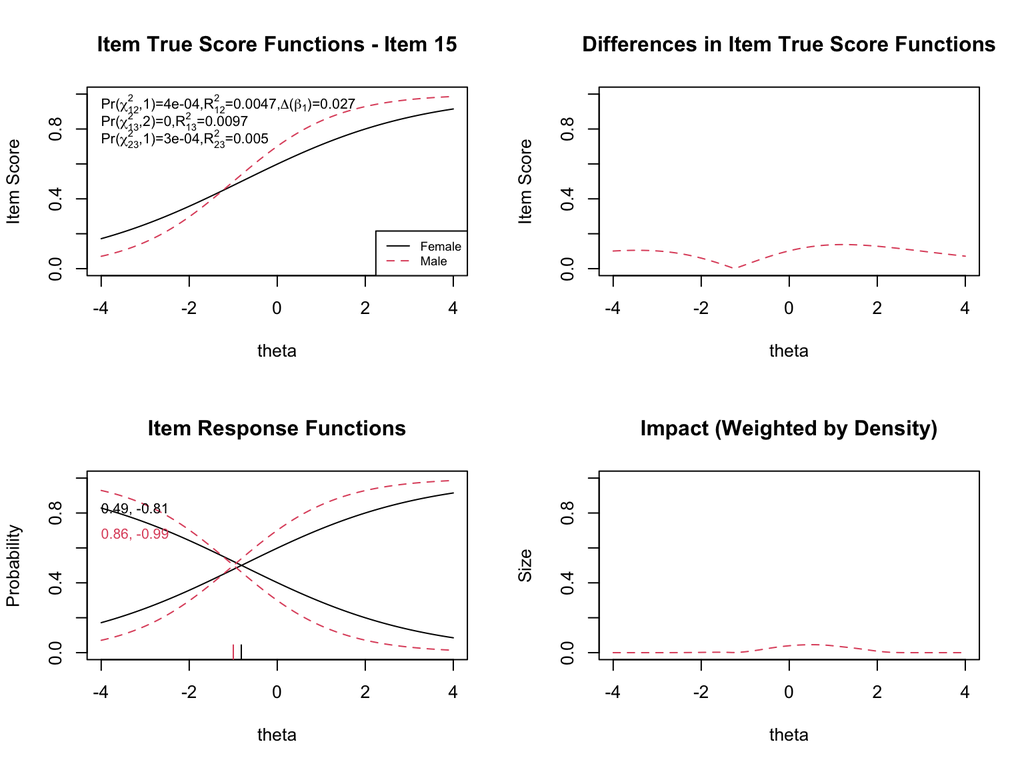

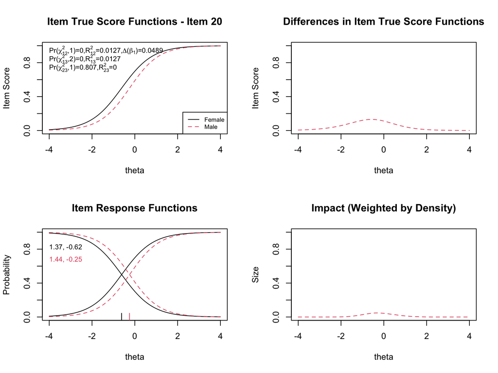

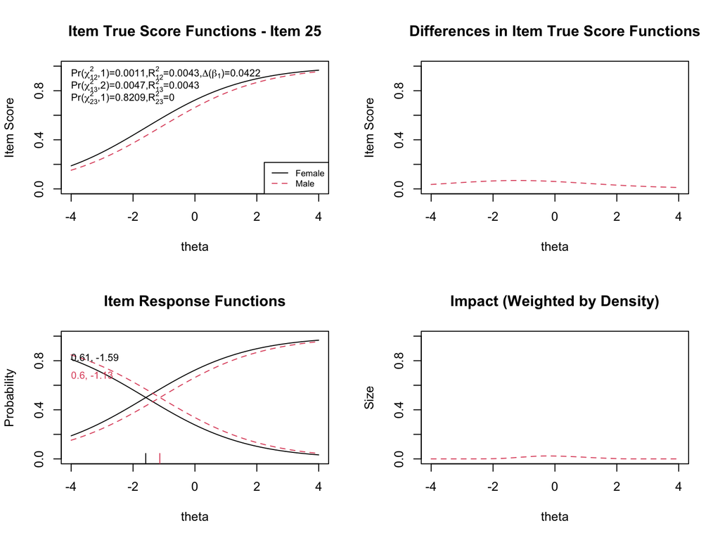

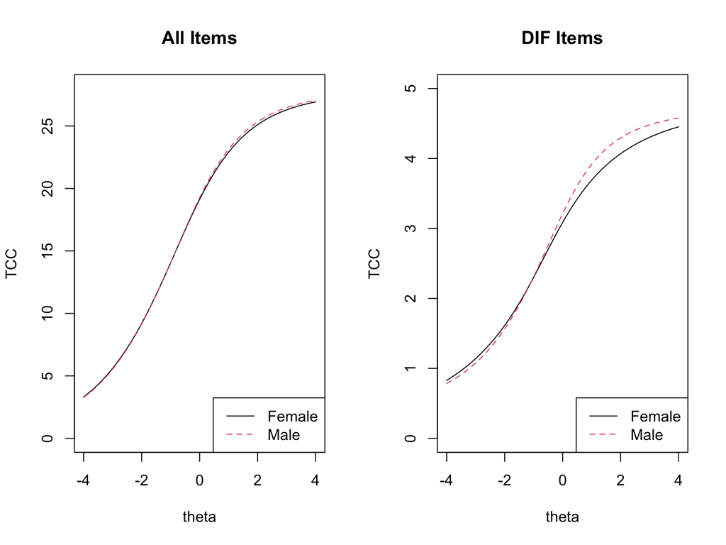

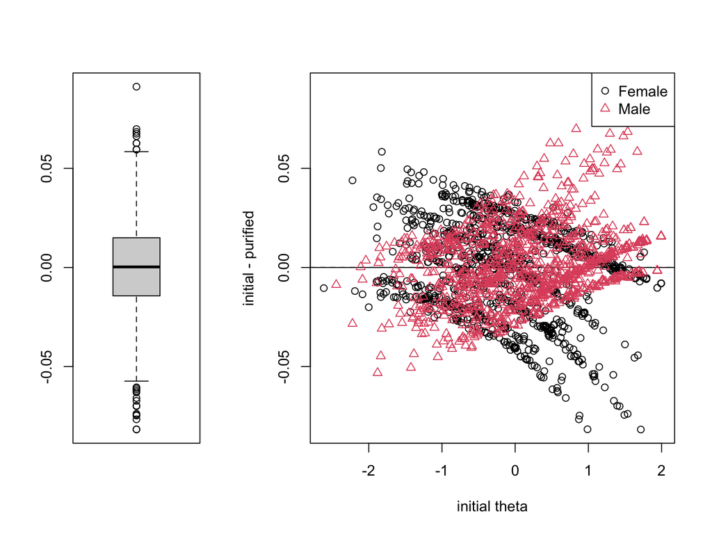

```r
plot(dif_result, labels = c("Female", "Male"), cex = 0.7)
```

It also helps to pull a few numerical summaries directly out of the `lordif` object. The initial trait estimates (ignoring DIF) are in `dif_result$calib$theta`; the purified trait estimates (accounting for DIF) are in `dif_result$calib.sparse$theta`. Group-specific item parameters for the flagged items are in `dif_result$ipar.sparse`.

```r
theta_init <- dif_result$calib$theta
theta_pur  <- dif_result$calib.sparse$theta
se_pur     <- dif_result$calib.sparse$SE
grp        <- DIF.data[, 29]

m_init_F <- mean(theta_init[grp == 0]); m_init_M <- mean(theta_init[grp == 1])
m_pur_F  <- mean(theta_pur[grp == 0]);  m_pur_M  <- mean(theta_pur[grp == 1])

cat("Initial theta  (no DIF adjustment):  F =", round(m_init_F, 3),
    " M =", round(m_init_M, 3),
    " M - F =", round(m_init_M - m_init_F, 3), "\n")
```

```
## Initial theta  (no DIF adjustment):  F = -0.138  M = 0.137  M - F = 0.275
```

```r
cat("Purified theta (DIF adjusted):       F =", round(m_pur_F, 3),
    " M =", round(m_pur_M, 3),
    " M - F =", round(m_pur_M - m_pur_F, 3), "\n")
```

```
## Purified theta (DIF adjusted):       F = -0.136  M = 0.135  M - F = 0.272
```

```r
cat("(The initial single-group calibration anchors the theta metric to\n")
```

```
## (The initial single-group calibration anchors the theta metric to
```

```r
cat(" population mean 0 and SD 1, so these mean differences are already\n")
```

```
##  population mean 0 and SD 1, so these mean differences are already
```

```r
cat(" in population-SD units.)\n\n")
```

```
##  in population-SD units.)
```

```r
shift <- theta_pur - theta_init
cat("Shift (purified - initial)\n")
```

```
## Shift (purified - initial)
```

```r
cat("  Mean for F:", round(mean(shift[grp == 0]), 3),
    "  Mean for M:", round(mean(shift[grp == 1]), 3), "\n")
```

```
##   Mean for F: 0.001   Mean for M: -0.002
```

```r
cat("  |shift| quantiles (50/75/95%):",
    round(quantile(abs(shift), c(0.5, 0.75, 0.95)), 3), "\n")
```

```
##   |shift| quantiles (50/75/95%): 0.015 0.024 0.043
```

```r
cat("  Max |shift|:", round(max(abs(shift)), 3), "logits\n")
```

```
##   Max |shift|: 0.091 logits
```

```r
cat("  Mean CSEM (purified theta):", round(mean(se_pur), 3), "logits\n")
```

```
##   Mean CSEM (purified theta): 0.468 logits
```

**Question 3b**: For each flagged item, describe the nature of the DIF: Is it uniform or non-uniform? Which group is advantaged? How large is the effect?

> *Compared to the generating values.* The true parameters were a difficulty shift of 1.0, 0.7, and 0.5 logits harder for females on items 5, 10, 15 (plus a 0.2-logit higher discrimination for males on item 15), and 0.5 and 0.7 logits harder for males on items 20 and 25. lordif recovers the direction of DIF correctly for every item, and the estimated magnitudes for items 10, 15, 20, and 25 are in the same ballpark as the truth (somewhat attenuated, as is typical when two group-specific calibrations are linked). Item 5 is the exception: its true discrimination of 0.27 is too low to support stable estimation of *b*, so the algorithm returns a much larger estimated threshold difference (~3.4 logits) than the true value (1.0 logit). This is a limitation of how the data were simulated rather than of lordif.

**Question 3c**: Examine the test-level impact plots (TCCs). Does DIF appear to amplify or cancel at the test level?

> The test-level impact plots show the two group-specific TCCs nearly on top of one another. To quantify this for an aggregate group comparison, we read the mean $\hat{\theta}$ difference directly in **population-SD units**, using the fact that the initial single-group calibration anchors the theta metric to SD = 1 by identification. In this dataset, $\bar{\theta}_M - \bar{\theta}_F$ is 0.275 SD units under the naive calibration and 0.272 SD units after purification—a change of about 0.003 SD. **DIF cancels at the test level.** This is the expected pattern given the mixed direction of the item-level DIF: three items (5, 10, 15) favor males and two (20, 25) favor females, and those opposing effects largely offset when scores are aggregated.

**Question 3d**: Examine the individual-level impact plot. What is the typical magnitude of score change when DIF is accounted for? Is this large relative to the standard error of measurement?

> Both benchmarks—population SD at the group level and CSEM at the individual level—agree that DIF has essentially no practical impact on this dataset. That agreement is expected when DIF cancels: there is no systematic directional bias to accumulate at either scale. The more revealing scenario is when the two benchmarks disagree, which is taken up in Question 5.

# 6 Exercise 4: Compare Methods

**Question 4a**: Create a table or list comparing which items were flagged by MH versus `lordif`. Which items were flagged by both methods? Which were flagged by only one?

```r
mh_flagged <- which(mh_pval < 0.05 & abs(delta) > 0.5)
lordif_flagged <- which(dif_result$flag)

cat("MH flagged items (p < .05 and |delta| > 0.5):", sort(mh_flagged), "\n")
```

```
## MH flagged items (p < .05 and |delta| > 0.5): 5 10 15 20 25
```

```r
cat("lordif flagged items:                         ", sort(lordif_flagged), "\n")
```

```
## lordif flagged items:                          5 10 15 20 25
```

```r
both <- intersect(mh_flagged, lordif_flagged)
mh_only <- setdiff(mh_flagged, lordif_flagged)
lordif_only <- setdiff(lordif_flagged, mh_flagged)

cat("\nFlagged by both:    ", if (length(both) > 0) both else "none", "\n")
```

```
##
## Flagged by both:     5 10 15 20 25
```

```r
cat("MH only:            ", if (length(mh_only) > 0) mh_only else "none", "\n")
```

```
## MH only:             none
```

```r
cat("lordif only:        ", if (length(lordif_only) > 0) lordif_only else "none", "\n")
```

```
## lordif only:         none
```

> Both methods flagged the same 5 items: **5, 10, 15, 20, and 25**. There is complete agreement between MH and `lordif` for this dataset. No items were flagged by only one method.

**Question 4b**: Why might the two methods disagree about certain items? Consider differences in the matching criterion, sensitivity to uniform vs. non-uniform DIF, and the iterative purification process.

> Although the methods agree in this case, they can disagree for several reasons:
> - **Matching criterion**: MH matches on observed total score, which is contaminated by the DIF items themselves. `lordif` uses IRT-based $\hat{\theta}$ estimates and iteratively purifies the matching criterion by removing DIF items—potentially yielding a less biased comparison.
> - **Sensitivity to DIF type**: MH is designed primarily for **uniform DIF** (constant odds ratio across ability levels). For **non-uniform DIF** (as in item 15, where the ICCs cross), MH averages over strata and may underestimate the effect or fail to detect it entirely. `lordif` tests separate parameters for uniform and non-uniform DIF via the logistic regression framework.
> - **Statistical criterion**: MH uses a chi-square test with a single degree of freedom; `lordif` uses a likelihood ratio chi-square comparing nested logistic regression models. The sensitivity and Type I error rates may differ.
> - **Purification**: `lordif`’s iterative purification means the IRT calibration used for matching progressively excludes DIF items, while MH uses a single total score throughout.

> In this dataset, the DIF effects are large enough that both methods detect them, but with subtler DIF or non-uniform DIF, `lordif` generally has an advantage.

**Question 4c**: Based on your full analysis, which items would you recommend for further content review by subject matter experts? Justify your recommendation.

> I would recommend **all 5 flagged items** (5, 10, 15, 20, 25) for content review. Items 10 and 20 are the highest priority because they show the largest effects (Level B by ETS criteria). Item 15 is noteworthy because it displays non-uniform DIF, which suggests that the item functions differently across the ability range—this may indicate that the item is tapping into a construct-irrelevant skill that interacts with both ability and gender. Items 5 and 25 show smaller but statistically significant effects.

> The content review should focus on whether the item content, wording, context, or format could plausibly advantage one gender group for reasons unrelated to the construct being measured. For example, items set in contexts more familiar to one gender (e.g., sports, cooking) could produce DIF without reflecting true ability differences.

# 7 Comparison to Ground Truth

Now that we have results from both methods, let’s compare them to the known generating parameters.

```r
# True DIF items and their properties
true_dif <- c(5, 10, 15, 20, 25)
true_direction <- c("Favors Males", "Favors Males", "Favors Males",
                     "Favors Females", "Favors Females")
true_type <- c("Uniform", "Uniform", "Non-uniform", "Uniform", "Uniform")
true_magnitude <- c("1.0 logits", "0.7 logits", "0.5 logits",
                     "0.5 logits", "0.7 logits")

# Detection results
mh_detected <- true_dif %in% mh_flagged
lordif_detected <- true_dif %in% lordif_flagged

# MH direction recovery
mh_dir <- ifelse(delta[true_dif] < 0, "Favors Males", "Favors Females")

comparison <- data.frame(
  Item = true_dif,
  True_Direction = true_direction,
  True_Type = true_type,
  Magnitude = true_magnitude,
  MH_Detected = ifelse(mh_detected, "Yes", "No"),
  MH_Direction = mh_dir,
  MH_Level = level[true_dif],
  lordif_Detected = ifelse(lordif_detected, "Yes", "No")
)

comparison |>
  kable("html",
        col.names = c("Item", "True Direction", "True DIF Type", "Magnitude",
                       "MH Detected?", "MH Direction", "MH Level",
                       "lordif Detected?")) |>
  kable_styling(full_width = FALSE)
```

| Item | True Direction | True DIF Type | Magnitude | MH Detected? | MH Direction | MH Level | lordif Detected? |
| --- | --- | --- | --- | --- | --- | --- | --- |
| 5 | Favors Males | Uniform | 1.0 logits | Yes | Favors Males | A | Yes |
| 10 | Favors Males | Uniform | 0.7 logits | Yes | Favors Males | B | Yes |
| 15 | Favors Males | Non-uniform | 0.5 logits | Yes | Favors Males | A | Yes |
| 20 | Favors Females | Uniform | 0.5 logits | Yes | Favors Females | B | Yes |
| 25 | Favors Females | Uniform | 0.7 logits | Yes | Favors Females | A | Yes |

```r
# False positives
mh_false_pos <- setdiff(mh_flagged, true_dif)
lordif_false_pos <- setdiff(lordif_flagged, true_dif)
cat("MH false positives:", if (length(mh_false_pos) > 0) mh_false_pos else "none", "\n")
```

```
## MH false positives: none
```

```r
cat("lordif false positives:", if (length(lordif_false_pos) > 0) lordif_false_pos else "none", "\n")
```

```
## lordif false positives: none
```

# 8 Exercise 5: Reflection

**Question 5**: Suppose you found strong evidence of DIF for several items, all favoring the same group. What are the implications for the validity of total score comparisons between groups? How would you advise a test developer who received these results?

> If DIF items consistently favor the same group, the effects **amplify** rather than cancel at the test level. This means the total score is systematically biased: one group’s expected score is inflated (or the other’s is deflated) relative to what their true ability would predict. This directly threatens the **validity** of between-group score comparisons—any observed mean difference confounds true ability differences (impact) with construct-irrelevant variance (bias).

> I would advise the test developer to:
> - **Conduct a content review** with subject matter experts to determine whether the DIF items share common features that could explain the bias (e.g., item format, context, language complexity).
> - **Consider removing or revising** the most problematic items, especially those at Level C. However, removing items may affect content coverage and reliability, so this must be balanced.
> - **Examine the test-level impact** using the TCC and individual-level plots. If the bias is large enough to change classification decisions (e.g., pass/fail), corrective action is urgent.
> - **Report the DIF analysis** as part of the technical documentation for the test, and flag the affected items for monitoring in future administrations.
> - **Investigate the root cause**: is the DIF due to item content (construct-irrelevant), or does it reflect real differential learning opportunities (construct-relevant)? Only the former represents a validity threat that should be addressed by revising the test.